# Projeto Airbnb Rio - Ferramenta de Previsão de Preço de Imóvel para pessoas comuns

### Contexto

No Airbnb, qualquer pessoa que tenha um quarto ou um imóvel de qualquer tipo (apartamento, casa, chalé, pousada, etc.) pode ofertar o seu imóvel para ser alugado por diária.

Você cria o seu perfil de host (pessoa que disponibiliza um imóvel para aluguel por diária) e cria o anúncio do seu imóvel.

Nesse anúncio, o host deve descrever as características do imóvel da forma mais completa possível, de forma a ajudar os locadores/viajantes a escolherem o melhor imóvel para eles (e de forma a tornar o seu anúncio mais atrativo)

Existem dezenas de personalizações possíveis no seu anúncio, desde quantidade mínima de diária, preço, quantidade de quartos, até regras de cancelamento, taxa extra para hóspedes extras, exigência de verificação de identidade do locador, etc.

### Nosso objetivo

Construir um modelo de previsão de preço que permita uma pessoa comum que possui um imóvel possa saber quanto deve cobrar pela diária do seu imóvel.

Ou ainda, para o locador comum, dado o imóvel que ele está buscando, ajudar a saber se aquele imóvel está com preço atrativo (abaixo da média para imóveis com as mesmas características) ou não.

### O que temos disponível, inspirações e créditos

As bases de dados foram retiradas do site kaggle: https://www.kaggle.com/allanbruno/airbnb-rio-de-janeiro

Elas estão disponíveis para download abaixo da aula (se você puxar os dados direto do Kaggle pode ser que encontre resultados diferentes dos meus, afinal as bases de dados podem ter sido atualizadas).

Caso queira uma outra solução, podemos olhar como referência a solução do usuário Allan Bruno do kaggle no Notebook: https://www.kaggle.com/allanbruno/helping-regular-people-price-listings-on-airbnb

Você vai perceber semelhanças entre a solução que vamos desenvolver aqui e a dele, mas também algumas diferenças significativas no processo de construção do projeto.

- As bases de dados são os preços dos imóveis obtidos e suas respectivas características em cada mês.
- Os preços são dados em reais (R$)
- Temos bases de abril de 2018 a maio de 2020, com exceção de junho de 2018 que não possui base de dados

### Expectativas Iniciais

- Acredito que a sazonalidade pode ser um fator importante, visto que meses como dezembro costumam ser bem caros no RJ
- A localização do imóvel deve fazer muita diferença no preço, já que no Rio de Janeiro a localização pode mudar completamente as características do lugar (segurança, beleza natural, pontos turísticos)
- Adicionais/Comodidades podem ter um impacto significativo, visto que temos muitos prédios e casas antigos no Rio de Janeiro

Vamos descobrir o quanto esses fatores impactam e se temos outros fatores não tão intuitivos que são extremamente importantes.

### Importar Bibliotecas e Bases de Dados

```python
import pandas as pd
from pathlib import Path
import numpy as np
import seaborn as sns
import matplotlib.pyplot as plt
import plotly.express as px
from sklearn.metrics import r2_score, mean_squared_error
from sklearn.linear_model import LinearRegression
from sklearn.ensemble import RandomForestRegressor, ExtraTreesRegressor
from sklearn.model_selection import train_test_split
```

### Consolidar Base de Dados

```python
meses = {"jan":1, "fev":2, "mar":3, "abr":4, "mai":5, "jun":6, "jul":7, "ago":8, "set":9, "out":10, "nov":11, "dez":12}
dataframe = pd.DataFrame()

for arquivo in Path("dataset").iterdir():
    df = pd.read_csv(arquivo)
    df["mes"] = meses[arquivo.name[:3]]
    df["ano"] = int(arquivo.name[-8:].replace(".csv", ""))
    dataframe = pd.concat([dataframe, df])
del df
```

```python
display(dataframe)
```

|  | id | listing_url | scrape_id | last_scraped | name | summary | space | description | experiences_offered | neighborhood_overview | ... | minimum_minimum_nights | maximum_minimum_nights | minimum_maximum_nights | maximum_maximum_nights | minimum_nights_avg_ntm | maximum_nights_avg_ntm | number_of_reviews_ltm | calculated_host_listings_count_entire_homes | calculated_host_listings_count_private_rooms | calculated_host_listings_count_shared_rooms |
| --- | --- | --- | --- | --- | --- | --- | --- | --- | --- | --- | --- | --- | --- | --- | --- | --- | --- | --- | --- | --- | --- |
| 0 | 14063 | https://www.airbnb.com/rooms/14063 | 20180414160018 | 2018-04-14 | Living in a Postcard | Besides the most iconic's view, our apartment ... | NaN | Besides the most iconic's view, our apartment ... | none | Best and favorite neighborhood of Rio. Perfect... | ... | NaN | NaN | NaN | NaN | NaN | NaN | NaN | NaN | NaN | NaN |
| 1 | 17878 | https://www.airbnb.com/rooms/17878 | 20180414160018 | 2018-04-14 | Very Nice 2Br - Copacabana - WiFi | Please note that special rates apply for New Y... | - large balcony which looks out on pedestrian ... | Please note that special rates apply for New Y... | none | This is the best spot in Rio. Everything happe... | ... | NaN | NaN | NaN | NaN | NaN | NaN | NaN | NaN | NaN | NaN |
| 2 | 24480 | https://www.airbnb.com/rooms/24480 | 20180414160018 | 2018-04-14 | Nice and cozy near Ipanema Beach | My studio is located in the best of Ipanema. ... | The studio is located at Vinicius de Moraes St... | My studio is located in the best of Ipanema. ... | none | The beach, the lagoon, Ipanema is a great loca... | ... | NaN | NaN | NaN | NaN | NaN | NaN | NaN | NaN | NaN | NaN |
| 3 | 25026 | https://www.airbnb.com/rooms/25026 | 20180414160018 | 2018-04-14 | Beautiful Modern Decorated Studio in Copa | Our apartment is a little gem, everyone loves ... | This newly renovated studio (last renovations ... | Our apartment is a little gem, everyone loves ... | none | Copacabana is a lively neighborhood and the ap... | ... | NaN | NaN | NaN | NaN | NaN | NaN | NaN | NaN | NaN | NaN |
| 4 | 31560 | https://www.airbnb.com/rooms/31560 | 20180414160018 | 2018-04-14 | NICE & COZY 1BDR - IPANEMA BEACH | This nice and clean 1 bedroom apartment is loc... | This nice and clean 1 bedroom apartment is loc... | This nice and clean 1 bedroom apartment is loc... | none | Die Nachbarschaft von Ipanema ist super lebend... | ... | NaN | NaN | NaN | NaN | NaN | NaN | NaN | NaN | NaN | NaN |
| ... | ... | ... | ... | ... | ... | ... | ... | ... | ... | ... | ... | ... | ... | ... | ... | ... | ... | ... | ... | ... | ... |
| 34324 | 38844730 | https://www.airbnb.com/rooms/38844730 | 20190923212307 | 2019-09-24 | TRANSAMERICA BARRA DA TIJUCA R IV | Em estilo contemporâneo, o Transamerica Prime ... | NaN | Em estilo contemporâneo, o Transamerica Prime ... | none | NaN | ... | 1.0 | 1.0 | 1125.0 | 1125.0 | 1.0 | 1125.0 | 0.0 | 15.0 | 0.0 | 0.0 |
| 34325 | 38846408 | https://www.airbnb.com/rooms/38846408 | 20190923212307 | 2019-09-24 | Alugo para o Rock in Rio | Confortável apartamento, 2 quartos , sendo 1 s... | O apartamento estará com mobília completa disp... | Confortável apartamento, 2 quartos , sendo 1 s... | none | Muito próximo ao Parque Olímpico, local do eve... | ... | 2.0 | 2.0 | 1125.0 | 1125.0 | 2.0 | 1125.0 | 0.0 | 1.0 | 0.0 | 0.0 |
| 34326 | 38846703 | https://www.airbnb.com/rooms/38846703 | 20190923212307 | 2019-09-24 | Apt COMPLETO em COPACABANA c/TOTAL SEGURANÇA | Apartamento quarto e sala COMPLETO para curtas... | Espaço ideal para até 5 pessoas. Cama de casal... | Apartamento quarto e sala COMPLETO para curtas... | none | NaN | ... | 3.0 | 3.0 | 1125.0 | 1125.0 | 3.0 | 1125.0 | 0.0 | 23.0 | 6.0 | 0.0 |
| 34327 | 38847050 | https://www.airbnb.com/rooms/38847050 | 20190923212307 | 2019-09-24 | Cobertura Cinematografica | Cobertura alto nivel | NaN | Cobertura alto nivel | none | NaN | ... | 1.0 | 1.0 | 1125.0 | 1125.0 | 1.0 | 1125.0 | 0.0 | 1.0 | 0.0 | 0.0 |
| 34328 | 38847655 | https://www.airbnb.com/rooms/38847655 | 20190923212307 | 2019-09-24 | Quarto em cobertura em frente à praia III | Quarto em cobertura quadriplex com vista lindí... | NaN | Quarto em cobertura quadriplex com vista lindí... | none | NaN | ... | 1.0 | 1.0 | 30.0 | 30.0 | 1.0 | 30.0 | 0.0 | 0.0 | 4.0 | 0.0 |

902210 rows × 108 columns

- Como temos muitas colunas, vamos identificar quais colunas podemos excluir
- Uma análise rápida permite ver que algumas colunas não são necessárias para o nosso modelo de previsão.
- Tipos de colunas para excluir:

  1- IDs, Links e informações não relevantes para o modelo 2- Colunas repetidas ou que dão a mesma informação para o modelo.Ex: Data x Ano/Mes 3- Colunas preenchidas com texto livre -> Não rodaremos nenhuma análise palavras ou algo do tipo 4- Colunas em que uma grande parte dos valores forem iguais
- Vamos salvar um arquivo com os primeiros 1000 items para uma analise qualitativa.

```python
dataframe.head(1000).to_csv("primeiros_registros.csv", sep=";", index=False)
```

### Depois da análise qualitativa, ficamos com as seguintes colunas:

```python
colunas = ['host_response_time', 'host_response_rate','host_is_superhost','host_listings_count','latitude','longitude','property_type','room_type','accommodates','bathrooms','bedrooms','beds','bed_type','amenities','price','security_deposit','cleaning_fee','guests_included','extra_people','minimum_nights','maximum_nights','number_of_reviews','review_scores_rating','review_scores_accuracy','review_scores_cleanliness','review_scores_checkin','review_scores_communication','review_scores_location','review_scores_value','instant_bookable','is_business_travel_ready','cancellation_policy','mes','ano']
df_airbnb = dataframe[colunas]

display(df_airbnb)
```

|  | host_response_time | host_response_rate | host_is_superhost | host_listings_count | latitude | longitude | property_type | room_type | accommodates | bathrooms | ... | review_scores_cleanliness | review_scores_checkin | review_scores_communication | review_scores_location | review_scores_value | instant_bookable | is_business_travel_ready | cancellation_policy | mes | ano |
| --- | --- | --- | --- | --- | --- | --- | --- | --- | --- | --- | --- | --- | --- | --- | --- | --- | --- | --- | --- | --- | --- |
| 0 | NaN | NaN | f | 1.0 | -22.946854 | -43.182737 | Apartment | Entire home/apt | 4 | 1.0 | ... | 9.0 | 9.0 | 9.0 | 9.0 | 9.0 | f | f | strict_14_with_grace_period | 4 | 2018 |
| 1 | within an hour | 100% | t | 2.0 | -22.965919 | -43.178962 | Condominium | Entire home/apt | 5 | 1.0 | ... | 9.0 | 10.0 | 10.0 | 9.0 | 9.0 | t | f | strict | 4 | 2018 |
| 2 | within an hour | 100% | f | 1.0 | -22.985698 | -43.201935 | Apartment | Entire home/apt | 2 | 1.0 | ... | 10.0 | 10.0 | 10.0 | 10.0 | 9.0 | f | f | strict | 4 | 2018 |
| 3 | within an hour | 100% | f | 3.0 | -22.977117 | -43.190454 | Apartment | Entire home/apt | 3 | 1.0 | ... | 10.0 | 10.0 | 10.0 | 10.0 | 9.0 | f | f | strict | 4 | 2018 |
| 4 | within an hour | 100% | t | 1.0 | -22.983024 | -43.214270 | Apartment | Entire home/apt | 3 | 1.0 | ... | 10.0 | 10.0 | 10.0 | 10.0 | 9.0 | t | f | strict | 4 | 2018 |
| ... | ... | ... | ... | ... | ... | ... | ... | ... | ... | ... | ... | ... | ... | ... | ... | ... | ... | ... | ... | ... | ... |
| 34324 | within an hour | 93% | f | 0.0 | -23.003180 | -43.342840 | Apartment | Entire home/apt | 4 | 1.0 | ... | NaN | NaN | NaN | NaN | NaN | f | f | flexible | 9 | 2019 |
| 34325 | NaN | NaN | f | 0.0 | -22.966640 | -43.393450 | Apartment | Entire home/apt | 4 | 2.0 | ... | NaN | NaN | NaN | NaN | NaN | f | f | flexible | 9 | 2019 |
| 34326 | within a few hours | 74% | f | 32.0 | -22.962080 | -43.175520 | Apartment | Entire home/apt | 5 | 1.0 | ... | NaN | NaN | NaN | NaN | NaN | f | f | strict_14_with_grace_period | 9 | 2019 |
| 34327 | NaN | NaN | f | 0.0 | -23.003400 | -43.341820 | Apartment | Entire home/apt | 4 | 1.0 | ... | NaN | NaN | NaN | NaN | NaN | f | f | strict_14_with_grace_period | 9 | 2019 |
| 34328 | a few days or more | 38% | f | 5.0 | -23.010560 | -43.363350 | Apartment | Private room | 2 | 0.0 | ... | NaN | NaN | NaN | NaN | NaN | f | f | strict_14_with_grace_period | 9 | 2019 |

902210 rows × 34 columns

### Tratar Valores Faltando

- Analisando o dataframe, encontramos muitas colunas com mais de 1/3 (300.000) dos valores NaN. Vamos excluir essas colunas.
- Iremos excluir apenas as linhas das colunas com valores NaN abaixo de 300.000.

```python
print(df_airbnb.shape)
print(df_airbnb.isna().sum())
```

```
(902210, 34)
host_response_time             401843
host_response_rate             401846
host_is_superhost                 460
host_listings_count               460
latitude                            0
longitude                           0
property_type                       0
room_type                           0
accommodates                        0
bathrooms                        1724
bedrooms                          850
beds                             2502
bed_type                            0
amenities                           0
price                               0
security_deposit               421280
cleaning_fee                   313506
guests_included                     0
extra_people                        0
minimum_nights                      0
maximum_nights                      0
number_of_reviews                   0
review_scores_rating           448016
review_scores_accuracy         448586
review_scores_cleanliness      448413
review_scores_checkin          448650
review_scores_communication    448415
review_scores_location         448553
review_scores_value            448551
instant_bookable                    0
is_business_travel_ready            0
cancellation_policy                 0
mes                                 0
ano                                 0
dtype: int64
```

```python
for coluna in df_airbnb:
    if df_airbnb[coluna].isna().sum() >= 300000:
        df_airbnb.pop(coluna)
df_airbnb = df_airbnb.dropna()
print(df_airbnb.shape)
print(df_airbnb.isna().sum())
```

```
(897709, 23)
host_is_superhost           0
host_listings_count         0
latitude                    0
longitude                   0
property_type               0
room_type                   0
accommodates                0
bathrooms                   0
bedrooms                    0
beds                        0
bed_type                    0
amenities                   0
price                       0
guests_included             0
extra_people                0
minimum_nights              0
maximum_nights              0
number_of_reviews           0
instant_bookable            0
is_business_travel_ready    0
cancellation_policy         0
mes                         0
ano                         0
dtype: int64
```

### Verificar Tipos de Dados em cada coluna

```python
print(df_airbnb.dtypes)
display(df_airbnb.iloc[0])
```

```
host_is_superhost            object
host_listings_count         float64
latitude                    float64
longitude                   float64
property_type                object
room_type                    object
accommodates                  int64
bathrooms                   float64
bedrooms                    float64
beds                        float64
bed_type                     object
amenities                    object
price                        object
guests_included               int64
extra_people                 object
minimum_nights                int64
maximum_nights                int64
number_of_reviews             int64
instant_bookable             object
is_business_travel_ready     object
cancellation_policy          object
mes                           int64
ano                           int64
dtype: object
```

```
host_is_superhost                                                           f
host_listings_count                                                       1.0
latitude                                                           -22.946854
longitude                                                          -43.182737
property_type                                                       Apartment
room_type                                                     Entire home/apt
accommodates                                                                4
bathrooms                                                                 1.0
bedrooms                                                                  0.0
beds                                                                      2.0
bed_type                                                             Real Bed
amenities                   {TV,Internet,"Air conditioning",Kitchen,Doorma...
price                                                                 $133.00
guests_included                                                             2
extra_people                                                           $34.00
minimum_nights                                                             60
maximum_nights                                                            365
number_of_reviews                                                          38
instant_bookable                                                            f
is_business_travel_ready                                                    f
cancellation_policy                               strict_14_with_grace_period
mes                                                                         4
ano                                                                      2018
Name: 0, dtype: object
```

- corrigindo tipos de algumas colunas

```python
# price extra_people
for coluna in ["price", "extra_people"]:
    df_airbnb[coluna] = (df_airbnb[coluna].str.replace("$", "")).str.replace(",", "")
    df_airbnb[coluna] = df_airbnb[coluna].astype(np.float32, copy=False)
print(df_airbnb.dtypes)
```

```
host_is_superhost            object
host_listings_count         float64
latitude                    float64
longitude                   float64
property_type                object
room_type                    object
accommodates                  int64
bathrooms                   float64
bedrooms                    float64
beds                        float64
bed_type                     object
amenities                    object
price                       float32
guests_included               int64
extra_people                float32
minimum_nights                int64
maximum_nights                int64
number_of_reviews             int64
instant_bookable             object
is_business_travel_ready     object
cancellation_policy          object
mes                           int64
ano                           int64
dtype: object
```

### Análise Exploratória e Tratar Outliers

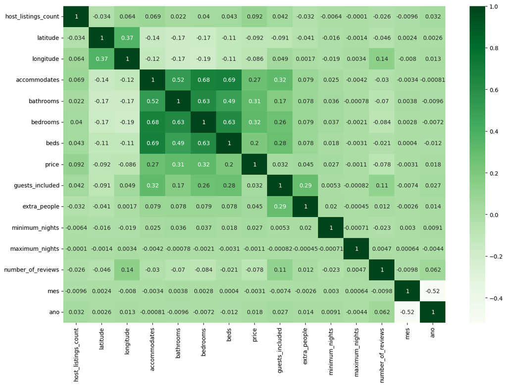

```python
plt.figure(figsize=(15,10))
sns.heatmap(df_airbnb.corr(numeric_only=True), annot=True, cmap="Greens")
```

### Definindo funções para identificar os outliers

```python
def limites(coluna):
    q1 = coluna.quantile(0.25)
    q3 = coluna.quantile(0.75)
    amplitude = q3 - q1
    return q1 - 1.5*amplitude, q3+1.5*amplitude

def remover_limites(df, coluna):
    lim_inf, lim_sup = limites(df[coluna])
    qtd_linhas = df.shape[0]
    df = df[(df[coluna] >= lim_inf)&(df[coluna]<=lim_sup)]
    print(f"Removido {qtd_linhas-df.shape[0]} linhas")
    return df

def plot_box(coluna):
    fig, axs = plt.subplots(1,2, figsize=(15,5))
    # fig.set_size_inches
    sns.boxplot(x=coluna, ax=axs[0])
    axs[1].set_xlim(limites(coluna))
    sns.boxplot(x=coluna, ax=axs[1])
    plt.show()

def histograma(coluna):
    plt.figure(figsize=(15,5))
    sns.histplot(x=coluna, kde=True)
    plt.show()

def barra(coluna):
    plt.figure(figsize=(15,5))
    bar = sns.barplot(x=coluna.value_counts().index, y=coluna.value_counts())
    min_lim, max_lim = limites(coluna)
    bar.set_xlim(min_lim, max_lim + 3)


def valores_categoria(coluna):
    plt.figure(figsize=(15,5))
    ax = sns.countplot(x=coluna)
    plt.xticks(rotation = 90)
    plt.show()
```

### price

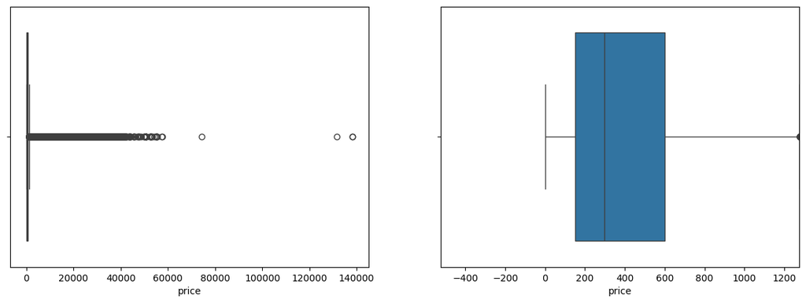

```python
plot_box(df_airbnb["price"])
```

```
Como o nosso modelo é destinado a imovéis comuns, vamos excluir os os preços acima do limite superior.
```

```
Removido 87282 linhas
(810427, 23)
```

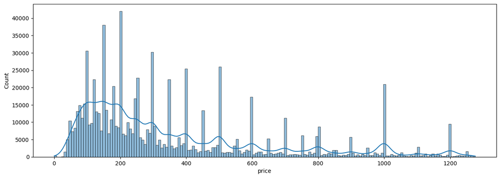

```python
df_airbnb = remover_limites(df_airbnb, "price")
print(df_airbnb.shape)
histograma(df_airbnb["price"])
```

### extra_people

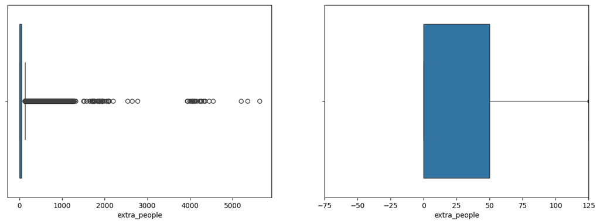

```python
plot_box(df_airbnb["extra_people"])
```

```
Removido 59194 linhas
(751233, 23)
```

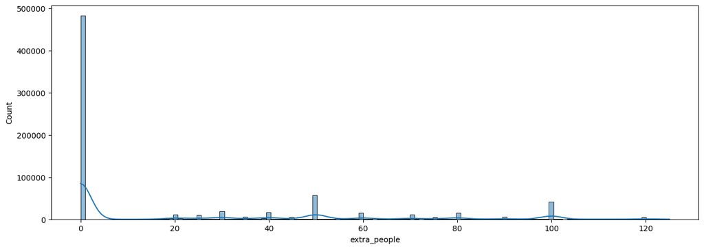

```python
df_airbnb = remover_limites(df_airbnb, "extra_people")
print(df_airbnb.shape)
histograma(df_airbnb["extra_people"])
```

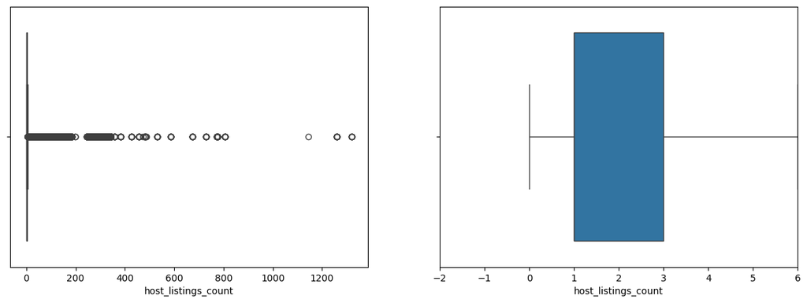

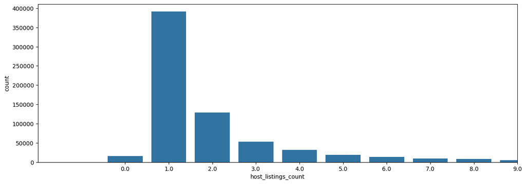

```python
plot_box(df_airbnb["host_listings_count"])
barra(df_airbnb["host_listings_count"])
```

```
Como o alvo do modelo são pessoas comuns, vamos eliminar os outliers da quantidade de imovéis, pois ao meu ver, são de imobiliarias.
```

```
Removido 97723 linhas
```

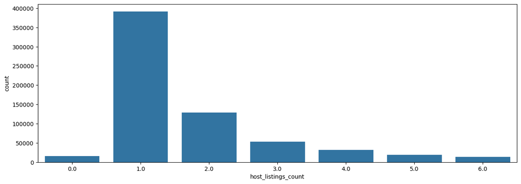

```python
df_airbnb = remover_limites(df_airbnb, "host_listings_count")
barra(df_airbnb["host_listings_count"])
```

### accommodates

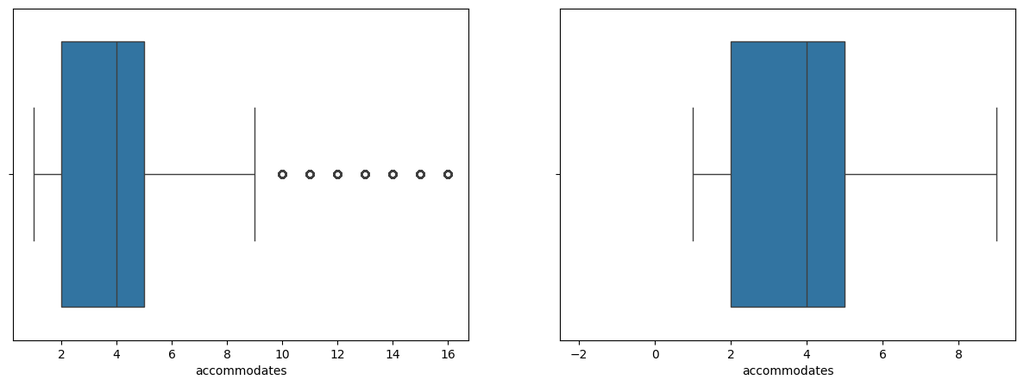

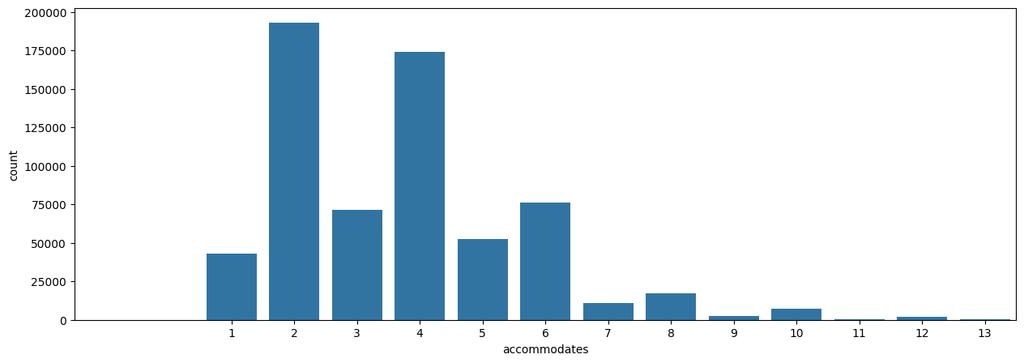

```python
plot_box(df_airbnb["accommodates"])
barra(df_airbnb["accommodates"])
```

```python
df_airbnb = remover_limites(df_airbnb, "accommodates")
```

```
Removido 13146 linhas
```

### bathrooms

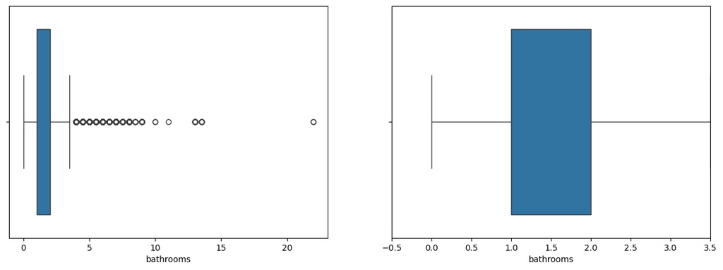

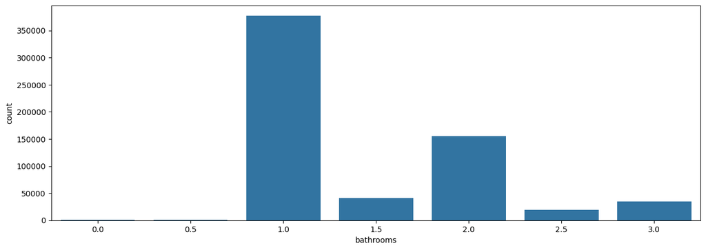

```python
plot_box(df_airbnb["bathrooms"])
barra(df_airbnb["bathrooms"])
```

```python
df_airbnb = remover_limites(df_airbnb, "bathrooms")
```

```
Removido 6894 linhas
```

### bedrooms

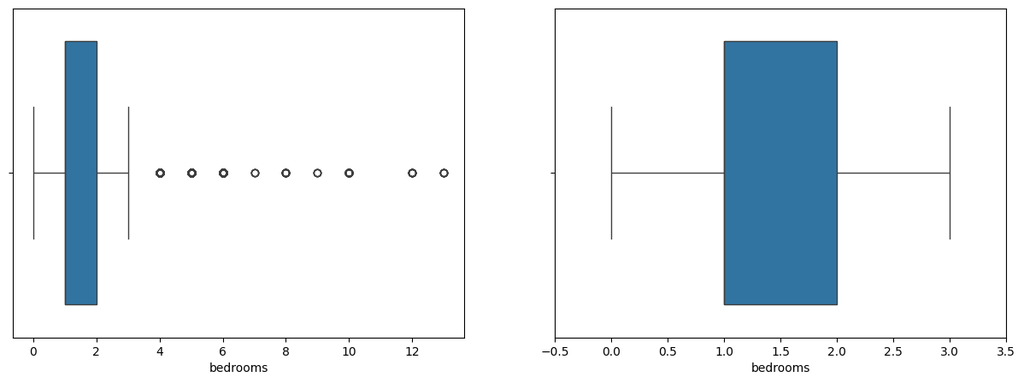

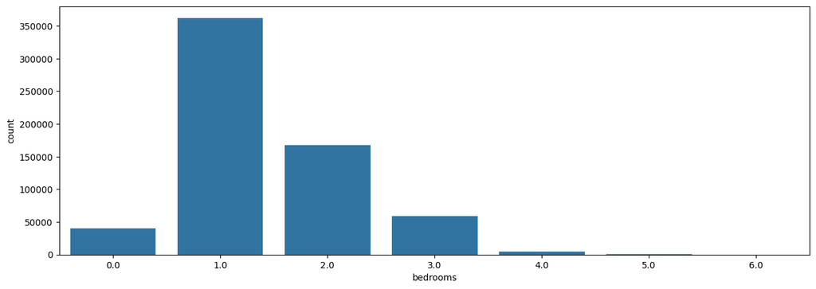

```python
plot_box(df_airbnb["bedrooms"])
barra(df_airbnb["bedrooms"])
```

```python
df_airbnb = remover_limites(df_airbnb, "bedrooms")
```

```
Removido 5482 linhas
```

### beds

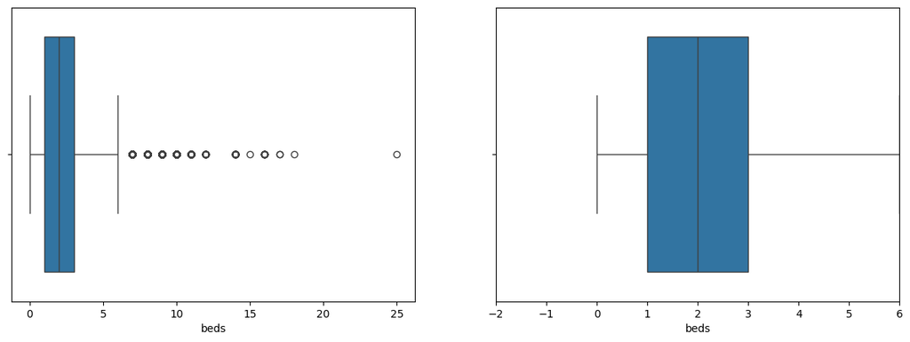

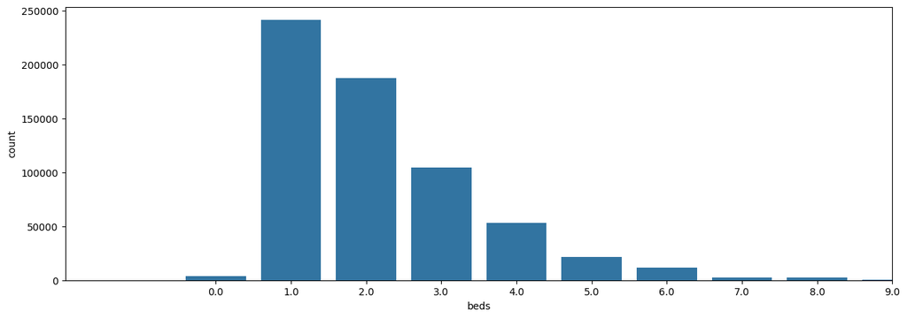

```python
plot_box(df_airbnb["beds"])
barra(df_airbnb["beds"])
```

```python
df_airbnb = remover_limites(df_airbnb, "beds")
```

```
Removido 5622 linhas
```

### guests_included

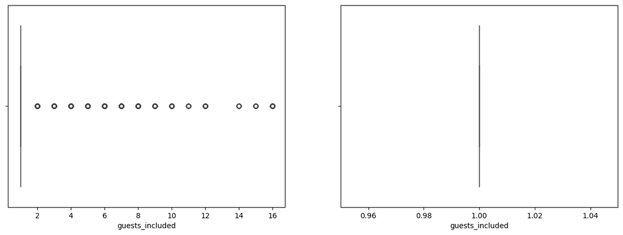

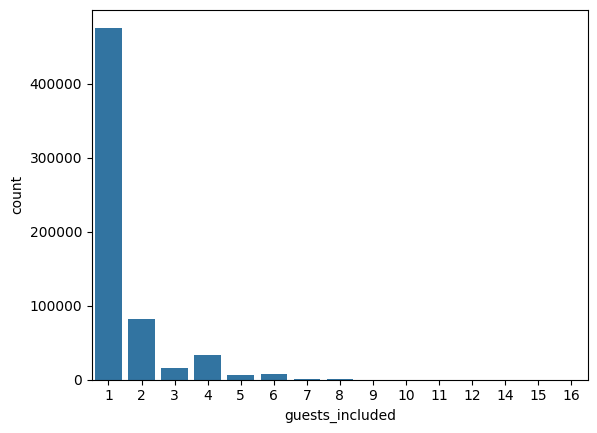

```python
plot_box(df_airbnb["guests_included"])
sns.barplot(x=df_airbnb["guests_included"].value_counts().index, y=df_airbnb["guests_included"].value_counts())
```

```
Parece que a maioria dos valores de guests_included, foram preenchidos com a forma padrão de 1. Por essa razão, iremos exclui-lo da análise
```

```python
print(df_airbnb.shape)
del df_airbnb["guests_included"]
print(df_airbnb.shape)
```

```
(622366, 23)
(622366, 22)
```

### minimum_nights

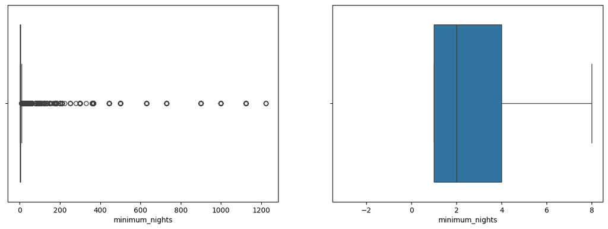

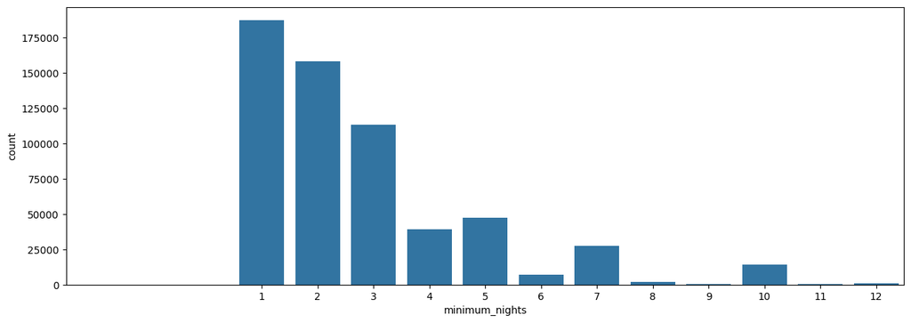

```python
plot_box(df_airbnb["minimum_nights"])
barra(df_airbnb["minimum_nights"])
```

```python
df_airbnb = remover_limites(df_airbnb, "minimum_nights")
```

```
Removido 40383 linhas
```

### maximum_nights

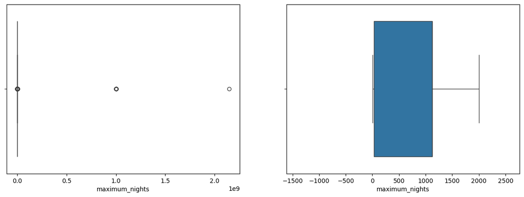

[figure not shown]

```python
plot_box(df_airbnb["maximum_nights"])
barra(df_airbnb["maximum_nights"])
```

```python
print(df_airbnb.shape)
del df_airbnb["maximum_nights"]
print(df_airbnb.shape)
```

```
(581983, 22)
(581983, 21)
```

### number_of_reviews

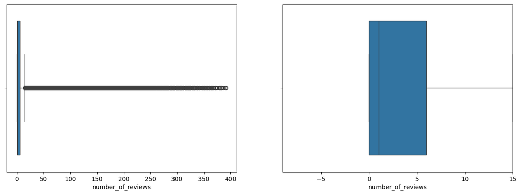

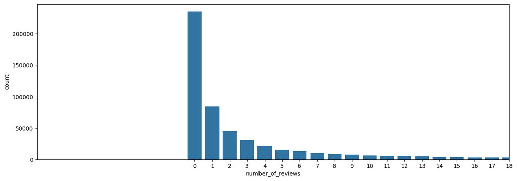

```python
plot_box(df_airbnb["number_of_reviews"])
barra(df_airbnb["number_of_reviews"])
```

```
Vamos remover os reviews, pois o modelo é para precificar os imovéis de pessoas comuns. No geral, um novo usuário não terá nenhuma review
```

```python
print(df_airbnb.shape)
del df_airbnb["number_of_reviews"]
print(df_airbnb.shape)
```

```
(581983, 21)
(581983, 20)
```

### Tratamento de colunas com valores de texto

- property_type

```
property_type
Apartment                 458354
House                      51387
Condominium                26456
Serviced apartment         12671
Loft                       12352
Guest suite                 3621
Bed and breakfast           3472
Hostel                      2665
Guesthouse                  2155
Other                       1957
Villa                       1294
Townhouse                    969
Aparthotel                   693
Chalet                       481
Earth house                  468
Tiny house                   457
Boutique hotel               447
Hotel                        376
Casa particular (Cuba)       298
Cottage                      230
Bungalow                     207
Dorm                         185
Cabin                        141
Nature lodge                 124
Castle                        80
Treehouse                     76
Island                        54
Boat                          53
Hut                           40
Campsite                      34
Resort                        31
Camper/RV                     24
Yurt                          23
Tent                          18
Tipi                          17
Barn                          15
Farm stay                     13
Pension (South Korea)          9
Dome house                     8
Igloo                          6
In-law                         6
Vacation home                  4
Timeshare                      3
Pousada                        3
Houseboat                      3
Casa particular                2
Plane                          1
Name: count, dtype: int64
```

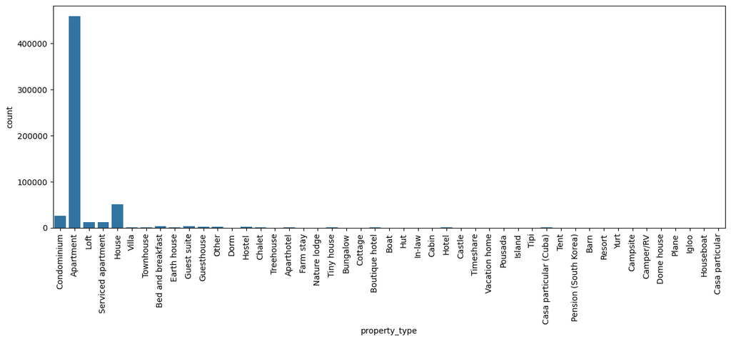

```python
print(df_airbnb["property_type"].value_counts())
valores_categoria(df_airbnb["property_type"])
```

```
Iremos alterar a categoria de todos os valores abaixo de 1500 para other
```

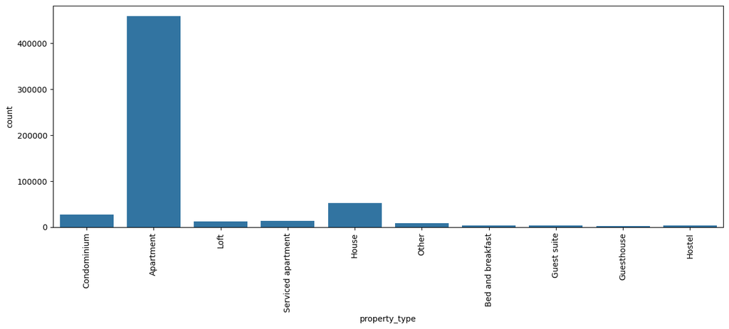

```python
for i in df_airbnb["property_type"].value_counts().index:
    if df_airbnb["property_type"].value_counts()[i] <= 1500:
        df_airbnb.loc[df_airbnb["property_type"]==i, "property_type"] = "Other"

valores_categoria(df_airbnb["property_type"])
```

- room_type

```
room_type
Entire home/apt    372443
Private room       196859
Shared room         11714
Hotel room            967
Name: count, dtype: int64
```

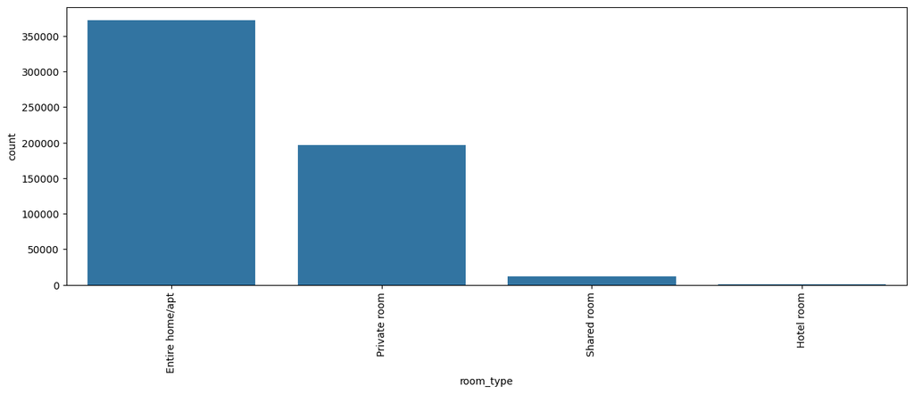

```python
print(df_airbnb["room_type"].value_counts())
valores_categoria(df_airbnb["room_type"])
```

- bed_type

```
bed_type
Real Bed         570643
Pull-out Sofa      8055
Futon              1634
Airbed             1155
Couch               496
Name: count, dtype: int64
```

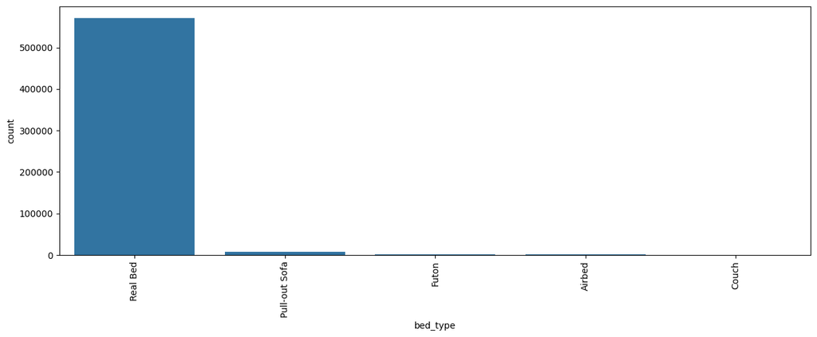

```python
print(df_airbnb["bed_type"].value_counts())
valores_categoria(df_airbnb["bed_type"])
```

```
Iremos alterar a categoria de todos os valores abaixo de 10000 para other
```